# Coursework 3

```python
import numpy as np
import scipy as sp
import scipy.io as sio
import matplotlib.pyplot as plt
import scipy.signal as sig
from sympy import diff
import scipy.stats as scs
import math
#load data
data=sio.loadmat('cw1_data2.mat')
dFonF=data['dFonF']
data1=sio.loadmat('cw1_data1.mat')
mouse_theta = data1 ['mouse_theta']
fs = data1['fs'].flatten()[0]    # frequency is the same as coursework 1
row =np.size(dFonF,0)#75
col =np.size(dFonF,1)#7420
t = np.linspace(0,(col-1)*1/fs,col) #build time serious matrix
```

## question 1

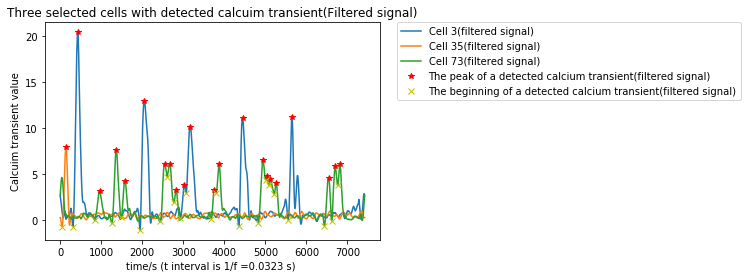

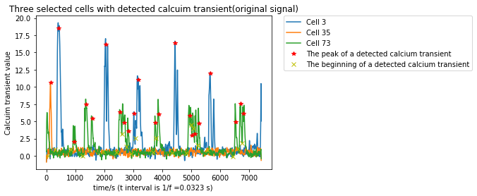

```python
## question 1
# define the findpeak function to find the location of peak and the beginning of the peak
def findpeak(y):
    # y is input signal
    dy=np.diff(y) #calculate the difference
    thres=3  # thres means threshold of peak valve.The choice of numerical value is obtained after many attempts.
    length_data=len(y)
    peak_width=65   #peak_width is the threshold distance between peaks.The choice of numerical value is obtained after many attempts.
    l = []
    for i in range(1,length_data-1):
            if y[i-1] <= y[i] and y[i] >= y[i+1] and y[i]>thres: #find the maximum value and meet the conditions greater than the threshold
                l.append(i);

    s = []
    len_l=len(l)
    if len_l > 2 :  #if find two peak position is below the width threshold, I think they belongs to the same peaks and only keep the larger value peak's position.
       for j in range(0,len_l-1):  #whether the two maximum points are the same peak.
          if l[j+1]-l[j]>peak_width:
               if y[j] >= y[j+1]:
                  s.append(l[j])
               else:
                  s.append(l[j+1]);         #if the distance between the peaks less than the peak_width threshold ,we think the two peaks belong to on calcium transient and only keep the larger peak location.
    else:
        s=l.copy()

    #find the beginning point
    min1=s.copy()     #use copy in case of change the value of s
    for i in range(0,len(s)):
        lag=s[i]    #Backward from the maximum point image, the first point where the difference is non-positive is the starting point
        while lag >= 0:
               lag =lag-1;
               if dy[lag] < 0:
                  min1[i]=lag; #The starting point is the first number from dy less than zero from back to front
                  break

    #plt.plot(min1,y[min1],'y*')

    return s,min1
#s means the peak location
#min1 means the beginning of the peak location


#yo=dFonF[3]
#y=sig.savgol_filter(yo,299,6,mode='wrap')#Too much noise may affect the determination of peak position.
#    #Because Savitzky-Golay filter has the advantage of preserving the area, position and width of peaks, so I choose this filter and find peak position on the filtered curve.
#    #Apply a Savitzky-Golay filter to an array in order to smooth data and remove noise.
#[s,min1]=findpeak(y)

yo1=dFonF[3]
y1=sig.savgol_filter(yo1,299,6,mode='wrap')#Too much noise may affect the determination of peak position.
    #Because Savitzky-Golay filter has the advantage of preserving the area, position and width of peaks, so I choose this filter and find peak position on the filtered curve.
    #Apply a Savitzky-Golay filter to an array in order to smooth data and remove noise.
[s1,min1]=findpeak(y1)  #use findpeak function and get the peaks location and the beginning location of the peak

yo2=dFonF[35]
y2=sig.savgol_filter(yo2,299,6,mode='wrap') #filtering
[s2,min2]=findpeak(y2) #use findpeak function and get the peaks location and the beginning location of the peak

yo3=dFonF[73]
y3=sig.savgol_filter(yo3,299,6,mode='wrap') #filtering
[s3,min3]=findpeak(y3)#use findpeak function and get the peaks location and the beginning location of the peak

# draw pictures to show results
# The first picture is based on the data after Savitzky-Golay filtering, which can more clearly show the peak and peak position
plt.figure(1)
plt.plot(y1,label='Cell 3(filtered signal)')
plt.plot(y2,label='Cell 35(filtered signal)')
plt.plot(y3,label='Cell 73(filtered signal)')
plt.plot(s1,y1[s1],'r*',label='The peak of a detected calcium transient(filtered signal)')
plt.plot(min1,y1[min1],'yx',label='The beginning of a detected calcium transient(filtered signal)')
plt.plot(s2,y2[s2],'r*')
plt.plot(min2,y2[min2],'yx')
plt.plot(s3,y3[s3],'r*')
plt.plot(min3,y3[min3],'yx')
plt.legend(loc=2, bbox_to_anchor=(1.05,1.0),borderaxespad = 0.)#add label
plt.title('Three selected cells with detected calcuim transient(Filtered signal)')
plt.xlabel('time/s (t interval is 1/f =0.0323 s) ')
plt.ylabel('Calcuim transient value')

# The second picture is based on original data
plt.figure(2)
plt.plot(yo1,label='Cell 3')
plt.plot(yo2,label='Cell 35')
plt.plot(yo3,label='Cell 73')
plt.plot(s1,yo1[s1],'r*',label='The peak of a detected calcium transient')
plt.plot(min1,yo1[min1],'yx',label='The beginning of a detected calcium transient')
plt.plot(s2,yo2[s2],'r*')
plt.plot(min2,yo2[min2],'yx')
plt.plot(s3,yo3[s3],'r*')
plt.plot(min3,yo3[min3],'yx')
plt.legend(loc=2, bbox_to_anchor=(1.05,1.0),borderaxespad = 0.)#add label
plt.title('Three selected cells with detected calcuim transient(original signal)')
plt.xlabel('time/s (t interval is 1/f =0.0323 s) ')
plt.ylabel('Calcuim transient value')
```

#### For question one,I choose three cell:cell 3 ,cell 35 and cell 73,and they have 6, 1, and 15 peak points, respectively.Number of peak represents how many times calcium transient happens.One peak means the neuron at this position is firing .So different number of peaks may indicates different cell status.

## question two

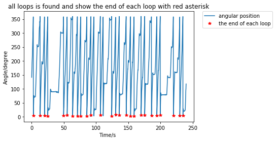

```python
# show the number of loop of the trak
turn = [] #turn means how many turns/loops of the circle
for i in range(1,len(mouse_theta)):
        delta=mouse_theta[i]-mouse_theta[i-1]
        if (delta < -200):          # a loop exists the adjacent angles diff by 200 degree(not 360 because there are some inevitabel errors in angular value)
         turn.append(i+1)

plt.figure()
plt.plot(t,mouse_theta,label='angular position')
plt.plot(t[turn],mouse_theta[turn],'r*',label='the end of each loop')
plt.title('all loops is found and show the end of each loop with red asterisk')
plt.xlabel('Time/s  ')
plt.ylabel('Angle/degree')
plt.legend(loc=2, bbox_to_anchor=(1.05,1.0),borderaxespad = 0.)#add label
```

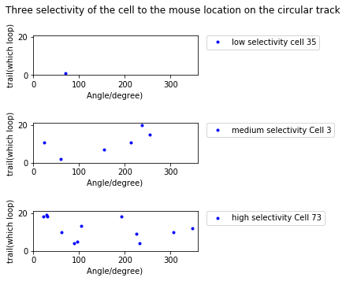

```python
#define the function to find which loop the peak is on
def response_peak(mouse_theta,s):
#mouse_theta is the angle data
#s is the peaks
    turn = [] #turn means how many turns/loops of the circle
    for i in range(1,len(mouse_theta)):
        delta=mouse_theta[i]-mouse_theta[i-1]
        if (delta < -200):          # a loop exists the adjacent angles diff by 200 degree(not 360 because there are some inevitabel errors in angular value)
         turn.append(i+1)
    #calculate which loop
    loop = np.zeros(len(s));
    for j in range(0,len(s)):
        for i in range(0,len(turn)):
          if (s[j] > turn[i]):      #Compare the position of the peak to the end of each loop position and decide which loop
           loop[j] = loop[j]+1;
    peak_angle=mouse_theta[s]
    return loop,peak_angle    #loop means indicates which loop around the track the mouse is on
    #peak_angle means the spatial angle of the mouse’s peak location
[loop1,peak_angle1]=response_peak(mouse_theta,s1)#use the function to find which loop the peak is on and spatial angle of the mouse’s peak location
[loop2,peak_angle2]=response_peak(mouse_theta,s2)
[loop3,peak_angle3]=response_peak(mouse_theta,s3)
fig=plt.figure()
plt.subplot(3,1,2)
plt.plot(peak_angle1,loop1,'b.',label='medium selectivity Cell 3')
plt.legend(loc=2, bbox_to_anchor=(1.05,1.0),borderaxespad = 0.)#add label
plt.ylim(0,21)
plt.xlim(0, 360);#angle from 0 to 360
plt.xlabel('Angle/degree) ')
plt.ylabel('trail(which loop)')
plt.subplot(3,1,1)
fig.tight_layout(pad=0.5, w_pad=3.0, h_pad=3.0) #adjust subplot params to avoid overlapping
plt.plot(peak_angle2,loop2,'b.',label='low selectivity cell 35')
plt.xlabel('Angle/degree) ')
plt.ylabel('trail(which loop)')
plt.legend(loc=2, bbox_to_anchor=(1.05,1.0),borderaxespad = 0.)#add label
plt.ylim(0,21)
plt.xlim(0, 360);
plt.subplot(3,1,3)
plt.plot(peak_angle3,loop3,'b.',label='high selectivity Cell 73')
plt.legend(loc=2, bbox_to_anchor=(1.05,1.0),borderaxespad = 0.)#add label
plt.ylim(0,21)
plt.xlim(0, 360);
plt.xlabel('Angle/degree) ')
plt.ylabel('trail(which loop)')
plt.suptitle('Three selectivity of cell to the mouse location on the circular track',y=1.1)
```

#### For three example cells showing high, medium and low selectivity of the firing of the cell to the mouse’s location on the circular track.By trails,low selectivity means the number of peaks is below 3.Medium selectivity means the number of peaks is below 4.Medium selectivity means the number of peaks is from 4 to 6.High selectivity means the number of peaks is above 6.The number of cell firing shows its selectivity for the location.From the gragh,we know that tt is difficult to predict the distribution regular because there are too few points.But we can find that the calcium calcium transients are likely to occur at some angles.Take high selectivity as example, calcium transients relatively concentrated around 100 and 225 degree.So I guess that the calcium signal mutation has a certain relationship with the movement position of the mouse.That is to say that when the nerve moves to a certain position, it will be firing.

## question three

```python
#define mutual_information function
#calculate the mutual information between the binary response variable and spatial angle, theta. Use 20 bins for spatial angle.
def mutual_information(yo,s,mouse_theta,bin_number):
    #y is input data
    #s is the location of peaks of y
    #mouse_theta is angle data
    res=np.zeros(len(yo))
    res[s]=1 #res is the binary response variable which means the spike location is 1 and others is 0
    #bin_number=20 #the number of bin is 20 here
    ang=np.round(mouse_theta/bin_number) #angle in 20 bins and rounding
    n=len(ang)
    ##Mutual information
    px=np.array([1-len(s)/len(yo),len(s)/len(yo)])#px is probabilty of event x = 0 or 1.  0 means no spike,1 means spike.
    py=np.zeros(bin_number)
    pxy=np.zeros((2,bin_number))
    p=1/n
    for i in range(n):
        py[int(ang[i])] += p  # py is probabilty of event y that which angle value occurs.
        pxy[int(res[i]),int(ang[i])] +=p   #pxy means the joint probability of x and y event happen together.
    # the pxy has 40 probability.with or without spikes and the corresponding angle value.
    Ixy=0 #Ixy is mutual information
    for i in range(2):
        for j in range(bin_number):
            if pxy[i,j] != 0:#denominator is not 0
                #Ixy=pxy[i,j]*math.log(pxy[i,j]/(px[i]*p[j])[,10])
                I = math.log(pxy[i,j]/(px[i]*py[j]),2)  # If the log base 2 is used, the units of mutual information are bits.
                Ixy += I*pxy[i,j]
    return Ixy

Ixy1=mutual_information(yo1,s1,mouse_theta,20)
print('Mutual information between the binary response variable and spatial angle of cell 3 is ',Ixy1)
Ixy2=mutual_information(yo2,s2,mouse_theta,20)
print('Mutual information between the binary response variable and spatial angle of cell 35 is ',Ixy2)
Ixy3=mutual_information(yo3,s3,mouse_theta,20)
print('Mutual information between the binary response variable and spatial angle of cell 73 is ',Ixy3)
```

```
Mutual information between the binary response variable and spatial angle of cell 3 is  0.0014800887187310415
Mutual information between the binary response variable and spatial angle of cell 35 is  0.000366678700335999
Mutual information between the binary response variable and spatial angle of cell 73 is  0.0018569890918667432
```

#### Anaysis: Mutual information is one of many quantities that measures how much one random variables tells us about another.From previous plots,I assume the mutual information value will be small value because the number of calcuim transient is too few.As the result shown,the value of mutual information between the binary response variable and spatial angle is very low,which means we can get very little information form the binary response variable to predict the spatial angle,vice versa.But the more calcuim transients occur, the greater the amount of mutual information.

## question four

```python
# define entropy function
def entropy(x):
    idx = x>0
    H = -np.sum( x[idx] * np.log2(x[idx]) ) #If the log base 2 is used, the units of mutual information are bits.
    return H  #H is the entropy

H = [] #H is Uncertainty (entropy) of the spatial location variable
for i in range(0,75):
    yo=dFonF[i,:]
    y=sig.savgol_filter(yo,299,6,mode='wrap')
    [s,min1]=findpeak(y)
    res=np.zeros(len(yo))
    res[s]=1 #res is the binary response variable which means the spike location is 1 and others is 0
    bin_number=20 #the number of bin is 20 here
    ang=np.round(mouse_theta/bin_number) #angle in 20 bins and rounding
    n=len(ang)
    px=np.array([1-len(s)/len(yo),len(s)/len(yo)])#px is probabilty of event x = 0 or 1.  0 means no spike,1 means spike.
    py=np.zeros(bin_number)
    pxy=np.zeros((2,bin_number))
    p=1/n
    for i in range(n):
        py[int(ang[i])] += p  # py is probabilty of event y that which angle value occurs.
        pxy[int(res[i]),int(ang[i])] +=p   #pxy means the joint probability of x and y event happen together.

    #H is Uncertainty (entropy) of the spatial location variable
    Hres=entropy(px)
    H.append(Hres);
Hmax=np.max(H)
print('Max entropy is ',Hmax)
```

```
Max entropy is  0.02100717388835926
```

#### Analysis: Entropy tells how much information there is in an event.If the log base 2 is used, the units of information are bits.The max entropy is 0.02100717388835926 bit and it occurs at cell 73 which also has the most number of calcium transient.The more certain or deterministic the event is, the less information it will contain.The probability distribution that best represents the current state of knowledge is the one with the largest (information) entropy.So the 'best 'cell is cell 73 which contains the maximum entropy.

## question five

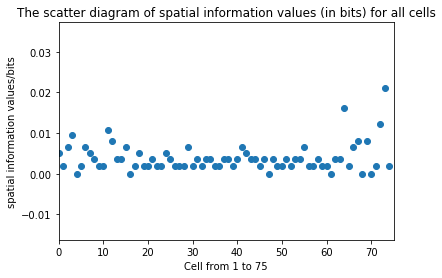

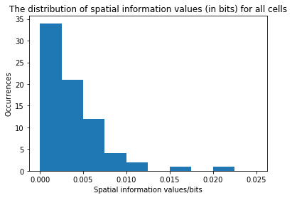

```python
H = [] #H is Uncertainty (entropy) of the spatial location variable
for i in range(0,75):
    yo=dFonF[i,:]
    y=sig.savgol_filter(yo,299,6,mode='wrap')
    [s,min1]=findpeak(y)
    res=np.zeros(len(yo))
    res[s]=1 #res is the binary response variable which means the spike location is 1 and others is 0
    bin_number=20 #the number of bin is 20 here
    ang=np.round(mouse_theta/bin_number) #angle in 20 bins and rounding
    n=len(ang)
    px=np.array([1-len(s)/len(yo),len(s)/len(yo)])#px is probabilty of event x = 0 or 1.  0 means no spike,1 means spike.
    py=np.zeros(bin_number)
    pxy=np.zeros((2,bin_number))
    p=1/n
    for i in range(n):
        py[int(ang[i])] += p  # py is probabilty of event y that which angle value occurs.
        pxy[int(res[i]),int(ang[i])] +=p   #pxy means the joint probability of x and y event happen together.

    #H is Uncertainty (entropy) of the spatial location variable
    Hres=entropy(px)
    H.append(Hres);


plt.figure()
plt.scatter(range(75),H)
plt.xlim(0,75)
plt.title("The scatter diagram of spatial information values (in bits) for all cells")
plt.xlabel("Cell from 1 to 75")
plt.ylabel("spatial information values/bits")

plt.figure()
# plot  distributions of spatial information values(in bit)
plt.hist(H,range =(0,0.025),bins=10) #number of bins is 10
plt.title("The distribution of spatial information values (in bits) for all cells")
plt.xlabel("Spatial information values/bits")
plt.ylabel("Occurrences")
```